# Research guide: county-year frame

3,144 county-equivalents (2023 delineation) x 25 years, 2000-2024: 78,600 rows, 354 variables

Research Guide

## Boolean

boolean · indicator

1

`pf_interp`

1 = foundation values interpolated (2016-18)

| ROWS | DISTINCT |
| --- | --- |
| 78,600 | 2 (0.0%) |

**PREVIEW**:

```
FALSE · TRUE
```

**CATEGORY LABELS**:

| FALSE | TRUE |
| --- | --- |

boolean

1

`bmf_src_monthly`

1 = 2023-24 counts from the NCCS monthly BMF

| ROWS | DISTINCT | MISSING/NA | ZERO |
| --- | --- | --- | --- |
| 78,600 | 3 (0.0%) | 122 (0.2%) | 72,192 (91.8%) |

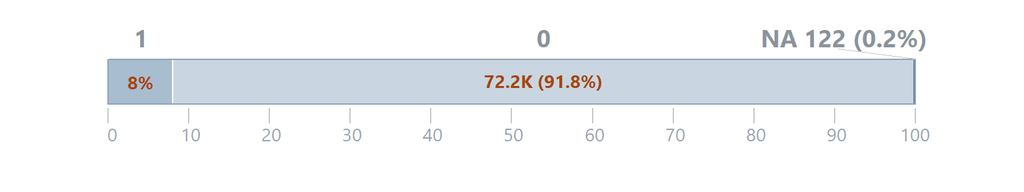

**PREVIEW**:

```
0 · 1
```

**CATEGORY LABELS**:

| 0 | 1 |
| --- | --- |

boolean

1

`entry_src_monthly`

1 = 2022-24 entries from the Dec 2024 monthly BMF (survivors only)

| ROWS | DISTINCT | ZERO |
| --- | --- | --- |
| 78,600 | 2 (0.0%) | 69,168 (88.0%) |

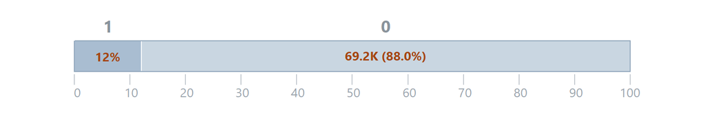

**PREVIEW**:

```
0 · 1
```

**CATEGORY LABELS**:

| 0 | 1 |
| --- | --- |

boolean · indicator

1

`post_splice_soi`

1 = year on or after the CORE -> SOI splice (2011)

| ROWS | DISTINCT |
| --- | --- |
| 78,600 | 2 (0.0%) |

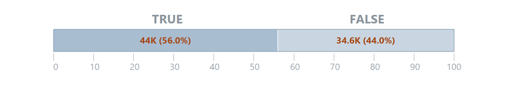

**PREVIEW**:

```
TRUE · FALSE
```

**CATEGORY LABELS**:

| FALSE | TRUE |
| --- | --- |

boolean · indicator

1

`post_splice_efile`

1 = year on or after the SOI -> e-file splice (2020)

| ROWS | DISTINCT |
| --- | --- |
| 78,600 | 2 (0.0%) |

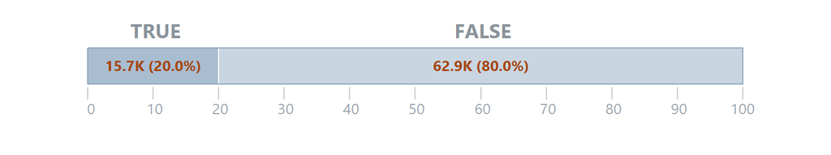

**PREVIEW**:

```
FALSE · TRUE
```

**CATEGORY LABELS**:

| FALSE | TRUE |
| --- | --- |

boolean

1

`qcew_fgov_imputed`

1 = suppressed county cell, imputed as state total minus disclosed counties, allocated by population: federal

| ROWS | DISTINCT | MISSING/NA | ZERO |
| --- | --- | --- | --- |
| 78,600 | 3 (0.0%) | 27 (0.0%) | 78,553 (99.9%) |

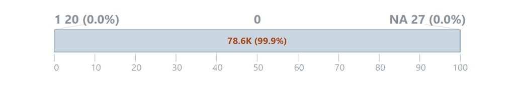

**PREVIEW**:

```
0 · 1
```

**CATEGORY LABELS**:

| 0 | 1 |
| --- | --- |

boolean

1

`patents_truncated`

1 = application year 2021+ (grant lag truncates counts)

| ROWS | DISTINCT | MISSING/NA | ZERO |
| --- | --- | --- | --- |
| 78,600 | 3 (0.0%) | 23,621 (30.1%) | 46,888 (59.7%) |

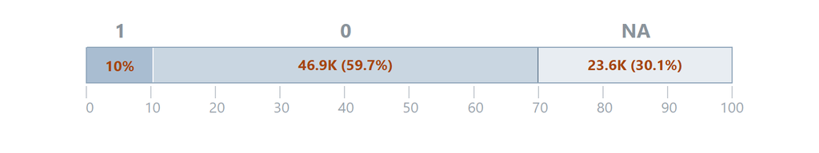

**PREVIEW**:

```
0 · 1
```

**CATEGORY LABELS**:

| 0 | 1 |
| --- | --- |

boolean

1

`rel_2000_noblack`

1 = 2000 file (historically Black bodies largely missing)

| ROWS | DISTINCT | MISSING/NA | ZERO |
| --- | --- | --- | --- |
| 78,600 | 3 (0.0%) | 69,170 (88.0%) | 6,288 (8.0%) |

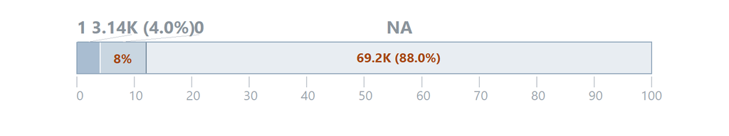

**PREVIEW**:

```
0 · 1
```

**CATEGORY LABELS**:

| 0 | 1 |
| --- | --- |

boolean

1

`socap_interp2000`

1 = 2000 interpolated from 1997 and 2005

| ROWS | DISTINCT | MISSING/NA | ZERO |
| --- | --- | --- | --- |
| 78,600 | 3 (0.0%) | 66,133 (84.1%) | 9,359 (11.9%) |

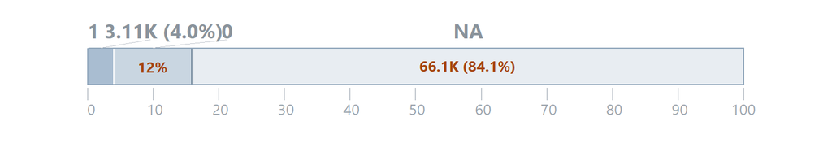

**PREVIEW**:

```
0 · 1
```

**CATEGORY LABELS**:

| 0 | 1 |
| --- | --- |

boolean · indicator

Share 25+ with BA+ (observed flag)

`pct_ba_obs`

Share 25+ with BA+. Observed flag: TRUE where the base value was observed that year, FALSE where it was filled.

| ROWS | DISTINCT |
| --- | --- |
| 78,600 | 2 (0.0%) |

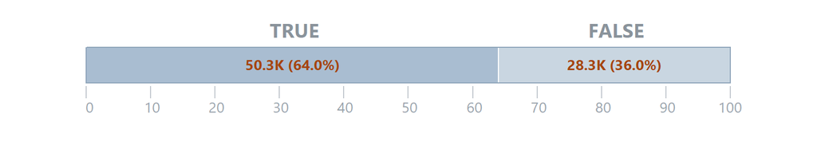

**PREVIEW**:

```
TRUE · FALSE
```

**CATEGORY LABELS**:

| FALSE | TRUE |
| --- | --- |

boolean · indicator

Foreign-born share (observed flag)

`pct_foreign_born_obs`

Foreign-born share. Observed flag: TRUE where the base value was observed that year, FALSE where it was filled. Identical to `pct_ba_obs` in this frame.

| ROWS | DISTINCT |
| --- | --- |
| 78,600 | 2 (0.0%) |

**PREVIEW**:

```
TRUE · FALSE
```

**CATEGORY LABELS**:

| FALSE | TRUE |
| --- | --- |

boolean · indicator

Household income Gini index (observed flag)

`gini_obs`

Household income Gini index. Observed flag: TRUE where the base value was observed that year, FALSE where it was filled.

| ROWS | DISTINCT |
| --- | --- |
| 78,600 | 2 (0.0%) |

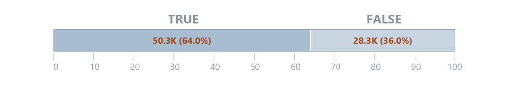

**PREVIEW**:

```
TRUE · FALSE
```

**CATEGORY LABELS**:

| FALSE | TRUE |
| --- | --- |

boolean · indicator

Presidential votes / population 18+ (observed flag)

`turnout_obs`

Presidential votes / population 18+. Observed flag: TRUE where the base value was observed that year, FALSE where it was filled.

| ROWS | DISTINCT |
| --- | --- |
| 78,600 | 2 (0.0%) |

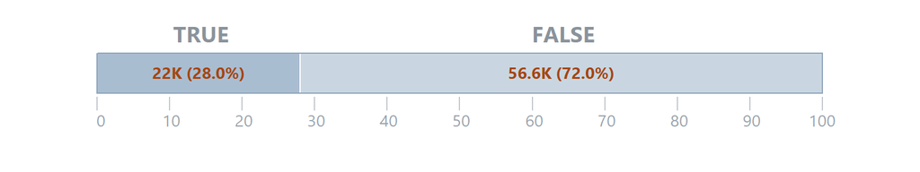

**PREVIEW**:

```
FALSE · TRUE
```

**CATEGORY LABELS**:

| FALSE | TRUE |
| --- | --- |

boolean · indicator

(votes_dem - votes_rep) / votes_total (observed flag)

`dem_margin_obs`

(votes_dem - votes_rep) / votes_total. Observed flag: TRUE where the base value was observed that year, FALSE where it was filled. Identical to `turnout_obs` in this frame.

| ROWS | DISTINCT |
| --- | --- |
| 78,600 | 2 (0.0%) |

**PREVIEW**:

```
FALSE · TRUE
```

**CATEGORY LABELS**:

| FALSE | TRUE |
| --- | --- |

boolean · indicator

Itemized charitable contributions, $ (observed flag)

`contrib_total_obs`

Itemized charitable contributions, $ (= a19700). Observed flag: TRUE where the base value was observed that year, FALSE where it was filled.

| ROWS | DISTINCT |
| --- | --- |
| 78,600 | 2 (0.0%) |

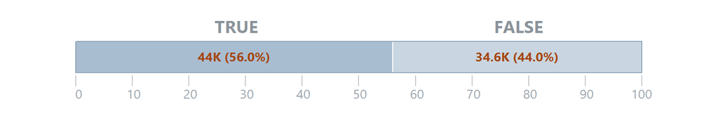

**PREVIEW**:

```
TRUE · FALSE
```

**CATEGORY LABELS**:

| FALSE | TRUE |
| --- | --- |

boolean · indicator

Itemized contributions per tax return (observed flag)

`contrib_per_return_obs`

Itemized contributions per tax return. Observed flag: TRUE where the base value was observed that year, FALSE where it was filled. Identical to `contrib_total_obs` in this frame.

| ROWS | DISTINCT |
| --- | --- |
| 78,600 | 2 (0.0%) |

**PREVIEW**:

```
TRUE · FALSE
```

**CATEGORY LABELS**:

| FALSE | TRUE |
| --- | --- |

boolean · indicator

Itemized contributions / AGI (observed flag)

`contrib_share_agi_obs`

Itemized contributions / AGI. Observed flag: TRUE where the base value was observed that year, FALSE where it was filled. Identical to `contrib_total_obs` in this frame.

| ROWS | DISTINCT |
| --- | --- |
| 78,600 | 2 (0.0%) |

**PREVIEW**:

```
TRUE · FALSE
```

**CATEGORY LABELS**:

| FALSE | TRUE |
| --- | --- |

boolean · indicator

HHI of adherent shares across religious bodies (observed flag)

`rel_hhi_obs`

HHI of adherent shares across religious bodies (0-1; higher = more concentrated). Observed flag: TRUE where the base value was observed that year, FALSE where it was filled.

| ROWS | DISTINCT |
| --- | --- |
| 78,600 | 2 (0.0%) |

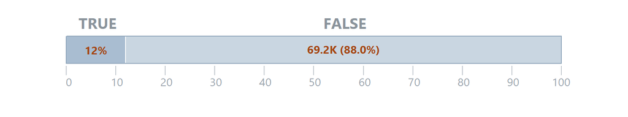

**PREVIEW**:

```
FALSE · TRUE
```

**CATEGORY LABELS**:

| FALSE | TRUE |
| --- | --- |

boolean · indicator

Religious adherents / population (observed flag)

`pct_adherent_obs`

Religious adherents / population. Observed flag: TRUE where the base value was observed that year, FALSE where it was filled.

| ROWS | DISTINCT |
| --- | --- |
| 78,600 | 2 (0.0%) |

**PREVIEW**:

```
FALSE · TRUE
```

**CATEGORY LABELS**:

| FALSE | TRUE |
| --- | --- |

boolean · indicator

Catholic adherents / all adherents (observed flag)

`pct_catholic_obs`

Catholic adherents / all adherents. Observed flag: TRUE where the base value was observed that year, FALSE where it was filled. Identical to `rel_hhi_obs` in this frame.

| ROWS | DISTINCT |
| --- | --- |
| 78,600 | 2 (0.0%) |

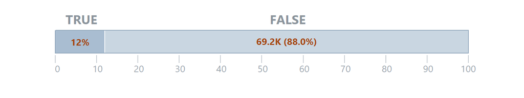

**PREVIEW**:

```
FALSE · TRUE
```

**CATEGORY LABELS**:

| FALSE | TRUE |
| --- | --- |

boolean · indicator

adherents (observed flag)

`rel_adh_obs`

adherents (count). Observed flag: TRUE where the base value was observed that year, FALSE where it was filled. Identical to `pct_adherent_obs` in this frame.

| ROWS | DISTINCT |
| --- | --- |
| 78,600 | 2 (0.0%) |

**PREVIEW**:

```
FALSE · TRUE
```

**CATEGORY LABELS**:

| FALSE | TRUE |
| --- | --- |

boolean · indicator

congregations (observed flag)

`rel_cng_obs`

congregations (count). Observed flag: TRUE where the base value was observed that year, FALSE where it was filled. Identical to `pct_adherent_obs` in this frame.

| ROWS | DISTINCT |
| --- | --- |
| 78,600 | 2 (0.0%) |

**PREVIEW**:

```
FALSE · TRUE
```

**CATEGORY LABELS**:

| FALSE | TRUE |
| --- | --- |

boolean · indicator

Catholic adherents (observed flag)

`rel_cath_adh_obs`

Catholic adherents (count). Observed flag: TRUE where the base value was observed that year, FALSE where it was filled. Identical to `pct_adherent_obs` in this frame.

| ROWS | DISTINCT |
| --- | --- |
| 78,600 | 2 (0.0%) |

**PREVIEW**:

```
FALSE · TRUE
```

**CATEGORY LABELS**:

| FALSE | TRUE |
| --- | --- |

boolean · indicator

association establishments (observed flag)

`socap_assn_n_obs`

association establishments (sum of 10 categories; CBP). Observed flag: TRUE where the base value was observed that year, FALSE where it was filled.

| ROWS | DISTINCT |
| --- | --- |
| 78,600 | 2 (0.0%) |

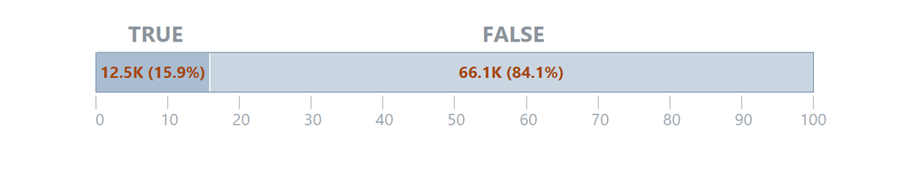

**PREVIEW**:

```
FALSE · TRUE
```

**CATEGORY LABELS**:

| FALSE | TRUE |
| --- | --- |

boolean · indicator

Census mail response rate (observed flag)

`socap_respn_obs`

Census mail response rate. Observed flag: TRUE where the base value was observed that year, FALSE where it was filled. Identical to `socap_assn_n_obs` in this frame.

| ROWS | DISTINCT |
| --- | --- |
| 78,600 | 2 (0.0%) |

**PREVIEW**:

```
FALSE · TRUE
```

**CATEGORY LABELS**:

| FALSE | TRUE |
| --- | --- |

boolean · indicator

published Rupasingha index (observed flag)

`socap_sk_obs`

published Rupasingha index (contains nccs = nonprofit density and pvote; validation / kitchen only). Observed flag: TRUE where the base value was observed that year, FALSE where it was filled. Identical to `socap_assn_n_obs` in this frame.

| ROWS | DISTINCT |
| --- | --- |
| 78,600 | 2 (0.0%) |

**PREVIEW**:

```
FALSE · TRUE
```

**CATEGORY LABELS**:

| FALSE | TRUE |
| --- | --- |

boolean · indicator

PC1 of log assn rate and respn, re-estimated per wave without nccs ... (observed flag)

`socap_sk2_obs`

PC1 of log assn rate and respn, re-estimated per wave without nccs and pvote. Observed flag: TRUE where the base value was observed that year, FALSE where it was filled. Identical to `socap_assn_n_obs` in this frame.

| ROWS | DISTINCT |
| --- | --- |
| 78,600 | 2 (0.0%) |

**PREVIEW**:

```
FALSE · TRUE
```

**CATEGORY LABELS**:

| FALSE | TRUE |
| --- | --- |

boolean · indicator

Local current operations, excl. utilities and liquor stores (observed flag)

`cog_curop_obs`

Local current operations, excl. utilities and liquor stores (E codes). Observed flag: TRUE where the base value was observed that year, FALSE where it was filled.

| ROWS | DISTINCT |
| --- | --- |
| 78,600 | 2 (0.0%) |

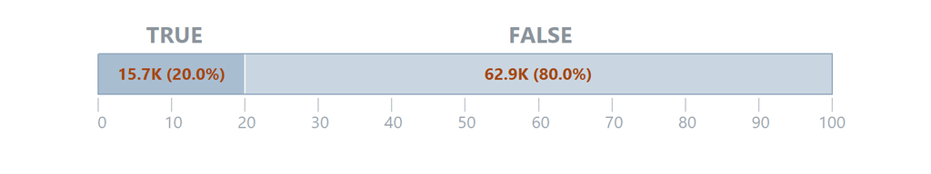

**PREVIEW**:

```
FALSE · TRUE
```

**CATEGORY LABELS**:

| FALSE | TRUE |
| --- | --- |

boolean · indicator

Local capital outlay, excl. utilities (observed flag)

`cog_capital_obs`

Local capital outlay, excl. utilities (F+G). Observed flag: TRUE where the base value was observed that year, FALSE where it was filled. Identical to `cog_curop_obs` in this frame.

| ROWS | DISTINCT |
| --- | --- |
| 78,600 | 2 (0.0%) |

**PREVIEW**:

```
FALSE · TRUE
```

**CATEGORY LABELS**:

| FALSE | TRUE |
| --- | --- |

boolean · indicator

Local assistance and subsidies (observed flag)

`cog_assist_obs`

Local assistance and subsidies (J). Observed flag: TRUE where the base value was observed that year, FALSE where it was filled. Identical to `cog_curop_obs` in this frame.

| ROWS | DISTINCT |
| --- | --- |
| 78,600 | 2 (0.0%) |

**PREVIEW**:

```
FALSE · TRUE
```

**CATEGORY LABELS**:

| FALSE | TRUE |
| --- | --- |

boolean · indicator

Local interest on general debt (observed flag)

`cog_interest_obs`

Local interest on general debt (I89). Observed flag: TRUE where the base value was observed that year, FALSE where it was filled. Identical to `cog_curop_obs` in this frame.

| ROWS | DISTINCT |
| --- | --- |
| 78,600 | 2 (0.0%) |

**PREVIEW**:

```
FALSE · TRUE
```

**CATEGORY LABELS**:

| FALSE | TRUE |
| --- | --- |

boolean · indicator

Local current operations, education (observed flag)

`cog_educ_curop_obs`

Local current operations, education (E12, E16, E18, E21). Observed flag: TRUE where the base value was observed that year, FALSE where it was filled. Identical to `cog_curop_obs` in this frame.

| ROWS | DISTINCT |
| --- | --- |
| 78,600 | 2 (0.0%) |

**PREVIEW**:

```
FALSE · TRUE
```

**CATEGORY LABELS**:

| FALSE | TRUE |
| --- | --- |

boolean · indicator

Local public welfare spending (observed flag)

`cog_welfare_obs`

Local public welfare spending (E/J 67, 68, 74, 75, 77, 79). Observed flag: TRUE where the base value was observed that year, FALSE where it was filled. Identical to `cog_curop_obs` in this frame.

| ROWS | DISTINCT |
| --- | --- |
| 78,600 | 2 (0.0%) |

**PREVIEW**:

```
FALSE · TRUE
```

**CATEGORY LABELS**:

| FALSE | TRUE |
| --- | --- |

boolean · indicator

Local health and hospitals current operations (observed flag)

`cog_health_curop_obs`

Local health and hospitals current operations (E32, E36, E38). Observed flag: TRUE where the base value was observed that year, FALSE where it was filled. Identical to `cog_curop_obs` in this frame.

| ROWS | DISTINCT |
| --- | --- |
| 78,600 | 2 (0.0%) |

**PREVIEW**:

```
FALSE · TRUE
```

**CATEGORY LABELS**:

| FALSE | TRUE |
| --- | --- |

boolean · indicator

Local salaries and wages (observed flag)

`cog_salaries_obs`

Local salaries and wages (Z00; not published for 2022). Observed flag: TRUE where the base value was observed that year, FALSE where it was filled.

| ROWS | DISTINCT |
| --- | --- |
| 78,600 | 2 (0.0%) |

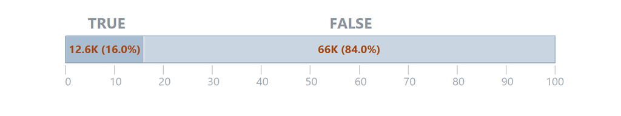

**PREVIEW**:

```
FALSE · TRUE
```

**CATEGORY LABELS**:

| FALSE | TRUE |
| --- | --- |

boolean · indicator

Local intergovernmental revenue from federal government (observed flag)

`cog_fed_igr_obs`

Local intergovernmental revenue from federal government (B). Observed flag: TRUE where the base value was observed that year, FALSE where it was filled. Identical to `cog_curop_obs` in this frame.

| ROWS | DISTINCT |
| --- | --- |
| 78,600 | 2 (0.0%) |

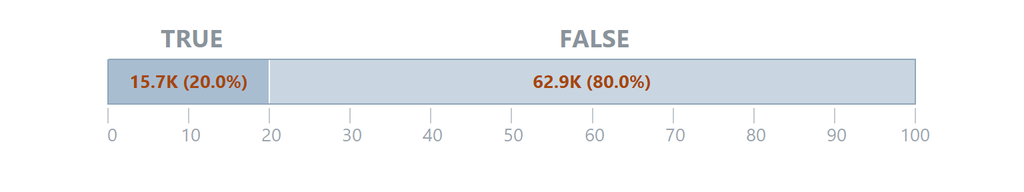

**PREVIEW**:

```
FALSE · TRUE
```

**CATEGORY LABELS**:

| FALSE | TRUE |
| --- | --- |

boolean · indicator

Local intergovernmental revenue from state government (observed flag)

`cog_state_igr_obs`

Local intergovernmental revenue from state government (C). Observed flag: TRUE where the base value was observed that year, FALSE where it was filled. Identical to `cog_curop_obs` in this frame.

| ROWS | DISTINCT |
| --- | --- |
| 78,600 | 2 (0.0%) |

**PREVIEW**:

```
FALSE · TRUE
```

**CATEGORY LABELS**:

| FALSE | TRUE |
| --- | --- |

boolean · indicator

Local direct general expenditure (observed flag)

`cog_dge_obs`

Local direct general expenditure = curop + capital + assist + interest. Observed flag: TRUE where the base value was observed that year, FALSE where it was filled. Identical to `cog_curop_obs` in this frame.

| ROWS | DISTINCT |
| --- | --- |
| 78,600 | 2 (0.0%) |

**PREVIEW**:

```
FALSE · TRUE
```

**CATEGORY LABELS**:

| FALSE | TRUE |
| --- | --- |

boolean · indicator

Personal current transfer receipts (observed flag)

`tr_total_obs`

Personal current transfer receipts. Observed flag: TRUE where the base value was observed that year, FALSE where it was filled.

| ROWS | DISTINCT |
| --- | --- |
| 78,600 | 2 (0.0%) |

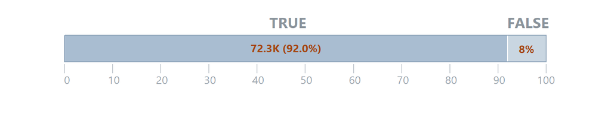

**PREVIEW**:

```
TRUE · FALSE
```

**CATEGORY LABELS**:

| FALSE | TRUE |
| --- | --- |

boolean · indicator

Transfer receipts of individuals from governments (observed flag)

`tr_gov_obs`

Transfer receipts of individuals from governments. Observed flag: TRUE where the base value was observed that year, FALSE where it was filled. Identical to `tr_total_obs` in this frame.

| ROWS | DISTINCT |
| --- | --- |
| 78,600 | 2 (0.0%) |

**PREVIEW**:

```
TRUE · FALSE
```

**CATEGORY LABELS**:

| FALSE | TRUE |
| --- | --- |

boolean · indicator

Social Security benefits (observed flag)

`tr_socsec_obs`

Social Security benefits. Observed flag: TRUE where the base value was observed that year, FALSE where it was filled. Identical to `tr_total_obs` in this frame.

| ROWS | DISTINCT |
| --- | --- |
| 78,600 | 2 (0.0%) |

**PREVIEW**:

```
TRUE · FALSE
```

**CATEGORY LABELS**:

| FALSE | TRUE |
| --- | --- |

boolean · indicator

Medical benefits (observed flag)

`tr_medical_obs`

Medical benefits (Medicare + Medicaid + military). Observed flag: TRUE where the base value was observed that year, FALSE where it was filled. Identical to `tr_total_obs` in this frame.

| ROWS | DISTINCT |
| --- | --- |
| 78,600 | 2 (0.0%) |

**PREVIEW**:

```
TRUE · FALSE
```

**CATEGORY LABELS**:

| FALSE | TRUE |
| --- | --- |

boolean · indicator

Medicare benefits (observed flag)

`tr_medicare_obs`

Medicare benefits. Observed flag: TRUE where the base value was observed that year, FALSE where it was filled. Identical to `tr_total_obs` in this frame.

| ROWS | DISTINCT |
| --- | --- |
| 78,600 | 2 (0.0%) |

**PREVIEW**:

```
TRUE · FALSE
```

**CATEGORY LABELS**:

| FALSE | TRUE |
| --- | --- |

boolean · indicator

Public assistance medical care (observed flag)

`tr_medicaid_obs`

Public assistance medical care (mostly Medicaid). Observed flag: TRUE where the base value was observed that year, FALSE where it was filled. Identical to `tr_total_obs` in this frame.

| ROWS | DISTINCT |
| --- | --- |
| 78,600 | 2 (0.0%) |

**PREVIEW**:

```
TRUE · FALSE
```

**CATEGORY LABELS**:

| FALSE | TRUE |
| --- | --- |

boolean · indicator

Income maintenance (observed flag)

`tr_income_maint_obs`

Income maintenance (SSI, EITC, SNAP, other). Observed flag: TRUE where the base value was observed that year, FALSE where it was filled. Identical to `tr_total_obs` in this frame.

| ROWS | DISTINCT |
| --- | --- |
| 78,600 | 2 (0.0%) |

**PREVIEW**:

```
TRUE · FALSE
```

**CATEGORY LABELS**:

| FALSE | TRUE |
| --- | --- |

boolean · indicator

SNAP benefits (observed flag)

`tr_snap_obs`

SNAP benefits. Observed flag: TRUE where the base value was observed that year, FALSE where it was filled. Identical to `tr_total_obs` in this frame.

| ROWS | DISTINCT |
| --- | --- |
| 78,600 | 2 (0.0%) |

**PREVIEW**:

```
TRUE · FALSE
```

**CATEGORY LABELS**:

| FALSE | TRUE |
| --- | --- |

boolean · indicator

Unemployment insurance compensation (observed flag)

`tr_unemp_obs`

Unemployment insurance compensation. Observed flag: TRUE where the base value was observed that year, FALSE where it was filled. Identical to `tr_total_obs` in this frame.

| ROWS | DISTINCT |
| --- | --- |
| 78,600 | 2 (0.0%) |

**PREVIEW**:

```
TRUE · FALSE
```

**CATEGORY LABELS**:

| FALSE | TRUE |
| --- | --- |

boolean · indicator

Veterans' benefits (observed flag)

`tr_veterans_obs`

Veterans' benefits. Observed flag: TRUE where the base value was observed that year, FALSE where it was filled. Identical to `tr_total_obs` in this frame.

| ROWS | DISTINCT |
| --- | --- |
| 78,600 | 2 (0.0%) |

**PREVIEW**:

```
TRUE · FALSE
```

**CATEGORY LABELS**:

| FALSE | TRUE |
| --- | --- |

boolean · indicator

Education and training assistance (observed flag)

`tr_education_obs`

Education and training assistance. Observed flag: TRUE where the base value was observed that year, FALSE where it was filled. Identical to `tr_total_obs` in this frame.

| ROWS | DISTINCT |
| --- | --- |
| 78,600 | 2 (0.0%) |

**PREVIEW**:

```
TRUE · FALSE
```

**CATEGORY LABELS**:

| FALSE | TRUE |
| --- | --- |

boolean · indicator

Transfer receipts of nonprofit institutions (observed flag)

`tr_nonprofit_obs`

Transfer receipts of nonprofit institutions (descriptive only). Observed flag: TRUE where the base value was observed that year, FALSE where it was filled. Identical to `tr_total_obs` in this frame.

| ROWS | DISTINCT |
| --- | --- |
| 78,600 | 2 (0.0%) |

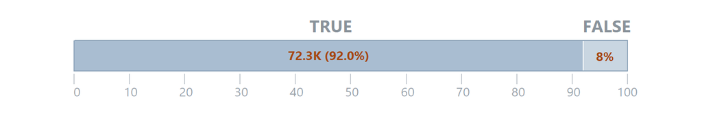

**PREVIEW**:

```
TRUE · FALSE
```

**CATEGORY LABELS**:

| FALSE | TRUE |
| --- | --- |

## Categorical

categorical · unordered

Source of the 990/990-EZ series that year: CORE 2000-10, SOI 2011-1...

`src_990`

Source of the 990/990-EZ series that year: CORE 2000-10, SOI 2011-19, e-file 2020-24

| ROWS | DISTINCT |
| --- | --- |
| 78,600 | 3 (0.0%) |

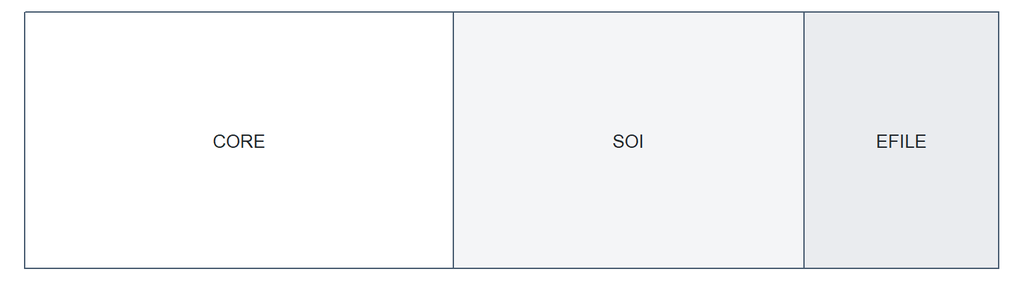

**PREVIEW**:

```
CORE · SOI · EFILE
```

**FACTOR LEVELS**:

| Frequency | (%) | Label |
| --- | --- | --- |
| 34,584 | (44.0%) | CORE |
| 28,296 | (36.0%) | SOI |
| 15,720 | (20.0%) | EFILE |

categorical · unordered

Source of the 990-PF series that year

`src_pf`

Source of the 990-PF series that year

| ROWS | DISTINCT |
| --- | --- |
| 78,600 | 4 (0.0%) |

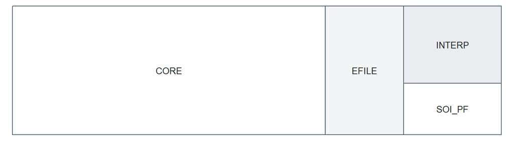

**PREVIEW**:

```
CORE · EFILE · INTERP · SOI_PF
```

**FACTOR LEVELS**:

| Frequency | (%) | Label |
| --- | --- | --- |
| 50,304 | (64.0%) | CORE |
| 12,576 | (16.0%) | EFILE |
| 9,432 | (12.0%) | INTERP |
| 6,288 | (8.0%) | SOI_PF |

categorical · unordered

Metropolitan or micropolitan statistical area

`cbsa_type`

Metropolitan or micropolitan statistical area

| ROWS | DISTINCT |
| --- | --- |
| 78,600 | 3 (0.0%) |

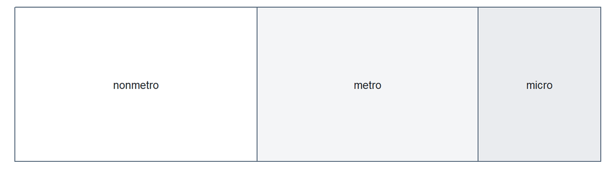

**PREVIEW**:

```
nonmetro · metro · micro
```

**FACTOR LEVELS**:

| Frequency | (%) | Label |
| --- | --- | --- |
| 32,500 | (41.3%) | nonmetro |
| 29,650 | (37.7%) | metro |
| 16,450 | (20.9%) | micro |

## Numeric

number

Resident population, Census PEP July 1

`population`

Resident population, Census PEP July 1

| ROWS | DISTINCT |
| --- | --- |
| 78,600 | 53,716 (68.3%) |

**PREVIEW**:

```
6022 · 14095 · 773 · 2174 · 5985 · 6873 · 7588 · 8602 · 8779 · 9260 · 12089 · 13474 · 15908
16953 · 25575 · 677 · 744 · 3086 · 3982 · 3995 · 4454 · 4744 · 5548 · 5998 · 6065 · 6582 · 6625
```

**STATS**:

| MIN | Q05 | Q25 | Q50 | MEAN | Q75 | Q95 | MAX |
| --- | --- | --- | --- | --- | --- | --- | --- |
| 43 | 2,806.95 | 10,981.75 | 25,596.5 | 99,505.98 | 66,673.25 | 429,962.5 | 10,125,014 |

number

Active filers, all 501(c) subsections

`n_filer_all`

Active filers, all 501(c) subsections (max(revenue, expenses) >= $50k in 2010 $)

| ROWS | DISTINCT | ZERO |
| --- | --- | --- |
| 78,600 | 2,075 (2.6%) | 1,123 (1.4%) |

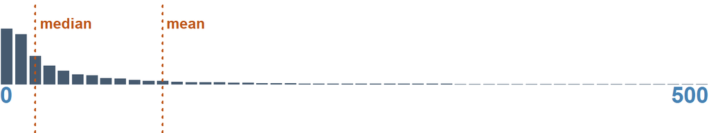

**PREVIEW**:

```
5 · 4 · 6 · 7 · 3 · 8 · 10 · 9 · 11 · 12 · 2 · 13 · 14 · 15 · 1 · 16 · 17 · 18 · 0 · 19 · 20
21 · 22 · 24 · 25 · 26 · 23 · 28 · 27 · 29 · 30 · 31 · 34 · 33 · 32 · 36 · 35 · 38 · 37 · 39
```

**STATS**:

| MIN | Q05 | Q25 | Q50 | MEAN | Q75 | Q95 | MAX |
| --- | --- | --- | --- | --- | --- | --- | --- |
| 0 | 2 | 10 | 25 | 114.88 | 74 | 497 | 11,059 |

number · measurement

Active 501(c)(3) 990/990-EZ filers

`n_filer_c3`

Active 501(c)(3) 990/990-EZ filers (same floor; 990-PF excluded)

| ROWS | DISTINCT | ZERO |
| --- | --- | --- |
| 78,600 | 1,725 (2.2%) | 2,222 (2.8%) |

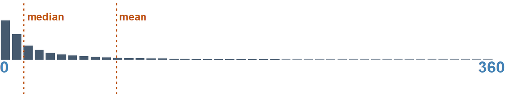

**PREVIEW**:

```
3 · 4 · 2 · 5 · 6 · 1 · 7 · 8 · 0 · 9 · 10 · 11 · 12 · 13 · 14 · 15 · 16 · 17 · 19 · 18 · 20
22 · 21 · 25 · 23 · 24 · 26 · 27 · 29 · 28 · 30 · 33 · 31 · 32 · 34 · 38 · 36 · 39 · 35 · 37
```

**STATS**:

| MIN | Q05 | Q25 | Q50 | MEAN | Q75 | Q95 | MAX |
| --- | --- | --- | --- | --- | --- | --- | --- |
| 0 | 1 | 6 | 17 | 83.3 | 53 | 356 | 9,217 |

number

Active c3 filers excluding hospitals

`n_filer_c3_nohu`

Active c3 filers excluding hospitals (NTEE E20-E24) and universities (B40-B43, B50)

| ROWS | DISTINCT | ZERO |
| --- | --- | --- |
| 78,600 | 1,726 (2.2%) | 2,470 (3.1%) |

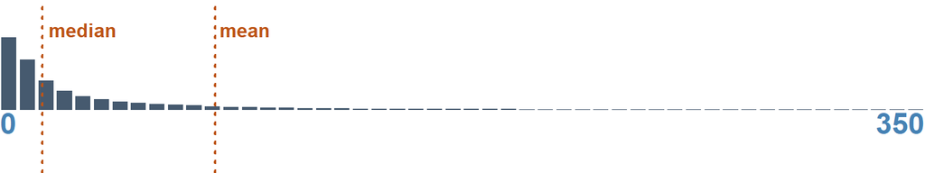

**PREVIEW**:

```
3 · 4 · 2 · 5 · 1 · 6 · 7 · 0 · 8 · 9 · 10 · 11 · 12 · 13 · 14 · 15 · 16 · 17 · 18 · 19 · 20
21 · 24 · 22 · 23 · 25 · 26 · 27 · 28 · 29 · 30 · 31 · 32 · 33 · 36 · 38 · 34 · 37 · 35 · 39
```

**STATS**:

| MIN | Q05 | Q25 | Q50 | MEAN | Q75 | Q95 | MAX |
| --- | --- | --- | --- | --- | --- | --- | --- |
| 0 | 1 | 6 | 16 | 81.38 | 51 | 348 | 9,082 |

number

Active c3 filers in human services

`n_filer_c3_hs`

Active c3 filers in human services (NTEE major groups I-P)

| ROWS | DISTINCT | ZERO |
| --- | --- | --- |
| 78,600 | 833 (1.1%) | 7,100 (9.0%) |

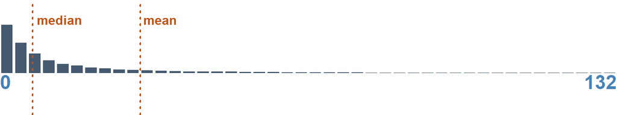

**PREVIEW**:

```
1 · 0 · 2 · 3 · 4 · 5 · 6 · 7 · 8 · 9 · 10 · 11 · 12 · 13 · 14 · 15 · 16 · 17 · 18 · 19 · 20
22 · 21 · 23 · 24 · 25 · 26 · 27 · 28 · 30 · 29 · 31 · 33 · 32 · 35 · 34 · 36 · 37 · 38 · 44
```

**STATS**:

| MIN | Q05 | Q25 | Q50 | MEAN | Q75 | Q95 | MAX |
| --- | --- | --- | --- | --- | --- | --- | --- |
| 0 | 0 | 2 | 7 | 30.04 | 21 | 131 | 2,930 |

number

All c3 990/990-EZ records, no size floor

`n_filer_c3_nofloor`

All c3 990/990-EZ records, no size floor

| ROWS | DISTINCT | ZERO |
| --- | --- | --- |
| 78,600 | 2,017 (2.6%) | 1,447 (1.8%) |

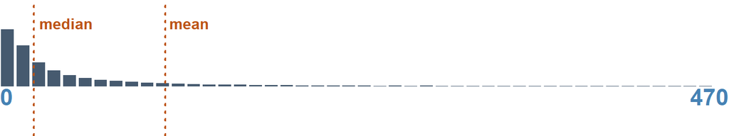

**PREVIEW**:

```
4 · 5 · 3 · 7 · 6 · 2 · 8 · 9 · 1 · 10 · 12 · 11 · 13 · 0 · 15 · 14 · 16 · 17 · 18 · 20 · 19
21 · 22 · 23 · 24 · 25 · 26 · 28 · 27 · 29 · 31 · 30 · 32 · 33 · 34 · 35 · 36 · 37 · 38 · 40
```

**STATS**:

| MIN | Q05 | Q25 | Q50 | MEAN | Q75 | Q95 | MAX |
| --- | --- | --- | --- | --- | --- | --- | --- |
| 0 | 2 | 8 | 22 | 106.72 | 68 | 463 | 12,701 |

number · measurement

Total expenses of active filers, all subsections

`exp_all`

Total expenses of active filers, all subsections (2022 $)

| ROWS | DISTINCT | ZERO |
| --- | --- | --- |
| 78,600 | 77,473 (98.6%) | 1,127 (1.4%) |

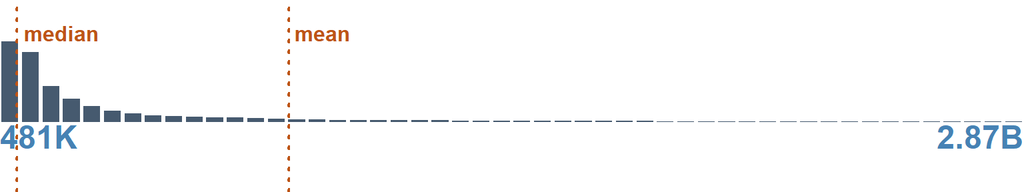

**PREVIEW**:

```
0 · 758777.857 · 379.442 · 1431.103 · 2414.631 · 2985.707 · 3208.762 · 3321.829 · 3652.651
4290.222 · 6446.244 · 6736.923 · 8150.138 · 8759.964 · 8889.871 · 11862.31 · 12305.683
```

**STATS**:

| MIN | Q05 | Q25 | Q50 | MEAN | Q75 | Q95 | MAX |
| --- | --- | --- | --- | --- | --- | --- | --- |
| 0 | 480,942.8 | 9,382,451 | 47,384,338 | 812,604,595 | 211,710,674 | 2,874,960,124 | 182,662,415,879 |

number · measurement

Total expenses of active c3 filers

`exp_c3`

Total expenses of active c3 filers (2022 $)

| ROWS | DISTINCT | ZERO |
| --- | --- | --- |
| 78,600 | 76,369 (97.2%) | 2,228 (2.8%) |

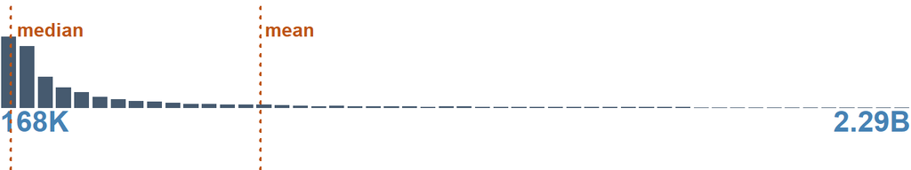

**PREVIEW**:

```
0 · 133732.216 · 936053.084 · 1591022.437 · 2260193.484 · 212.011 · 227.42 · 379.442 · 416.059
442.446 · 856.128 · 1431.103 · 1710.911 · 1910.447 · 2149.639 · 2414.631 · 2835 · 2985.707
```

**STATS**:

| MIN | Q05 | Q25 | Q50 | MEAN | Q75 | Q95 | MAX |
| --- | --- | --- | --- | --- | --- | --- | --- |
| 0 | 167,544.6 | 4,455,742 | 28,019,692 | 656,314,641 | 157,938,353 | 2,294,035,395 | 152,702,775,785 |

number · measurement

Total expenses of active c3 filers excluding hospitals and universi...

`exp_c3_nohu`

Total expenses of active c3 filers excluding hospitals and universities (2022 $)

| ROWS | DISTINCT | ZERO |
| --- | --- | --- |
| 78,600 | 76,117 (96.8%) | 2,478 (3.2%) |

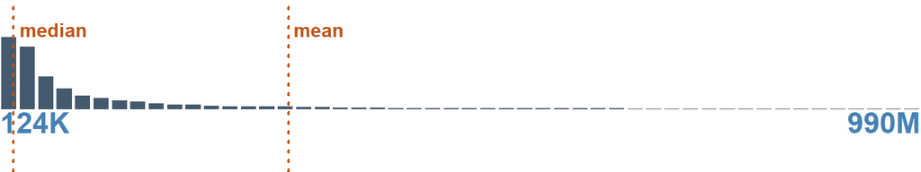

**PREVIEW**:

```
0 · 133732.216 · 549361.601 · 936053.084 · 1591022.437 · 2260193.484 · 4826091.755 · 212.011
227.42 · 379.442 · 416.059 · 442.446 · 628.449 · 751.366 · 856.128 · 1431.103 · 1510.19
```

**STATS**:

| MIN | Q05 | Q25 | Q50 | MEAN | Q75 | Q95 | MAX |
| --- | --- | --- | --- | --- | --- | --- | --- |
| 0 | 124,354.7 | 2,854,352 | 14,567,295 | 310,555,835 | 70,802,395 | 989,639,035 | 90,451,896,103 |

number · measurement

Total expenses of active human-services c3 filers

`exp_c3_hs`

Total expenses of active human-services c3 filers (2022 $)

| ROWS | DISTINCT | ZERO |
| --- | --- | --- |
| 78,600 | 71,484 (90.9%) | 7,109 (9.0%) |

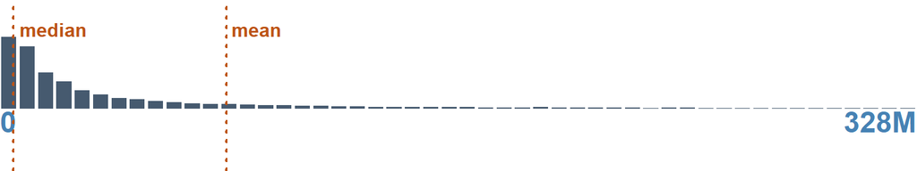

**PREVIEW**:

```
0 · 152680.402 · 204925.499 · 243418.891 · 553304.559 · 578852.121 · 801173.515 · 5654922.817
21187346.644 · 41.226 · 206.309 · 379.442 · 866.092 · 884.986 · 885.365 · 1124.007 · 1326.858
```

**STATS**:

| MIN | Q05 | Q25 | Q50 | MEAN | Q75 | Q95 | MAX |
| --- | --- | --- | --- | --- | --- | --- | --- |
| 0 | 0 | 662,335.7 | 4,793,424 | 81,200,867 | 27,612,560 | 328,275,270 | 18,836,280,949 |

number · measurement

Total revenue of active c3 filers

`rev_c3`

Total revenue of active c3 filers (2022 $)

| ROWS | DISTINCT | ZERO |
| --- | --- | --- |
| 78,600 | 76,369 (97.2%) | 2,229 (2.8%) |

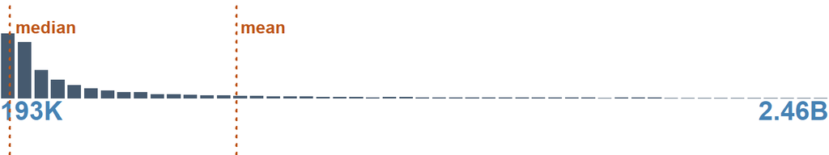

**PREVIEW**:

```
0 · 148045.325 · 4509265.394 · 6962109.595 · 14993.858 · 15525.734 · 20423.433 · 23234.812
24248.316 · 24475.729 · 25273.693 · 28365 · 29177.032 · 29250.99 · 32289.052 · 32372.088
```

**STATS**:

| MIN | Q05 | Q25 | Q50 | MEAN | Q75 | Q95 | MAX |
| --- | --- | --- | --- | --- | --- | --- | --- |
| 0 | 193,337.9 | 4,893,179 | 29,827,364 | 703,016,954 | 168,325,915 | 2,461,545,522 | 161,627,949,977 |

number · measurement

Total revenue, excluding hospitals and universities

`rev_c3_nohu`

Total revenue, excluding hospitals and universities (2022 $)

| ROWS | DISTINCT | ZERO |
| --- | --- | --- |
| 78,600 | 76,122 (96.8%) | 2,476 (3.2%) |

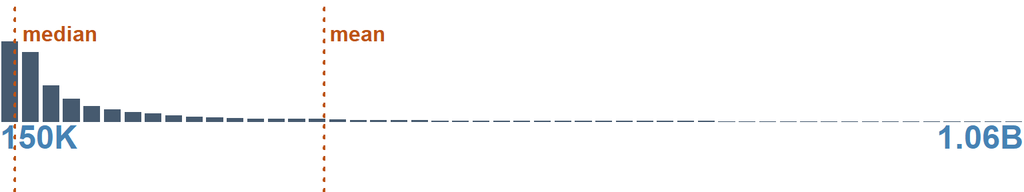

**PREVIEW**:

```
0 · 148045.325 · 4509265.394 · 6962109.595 · 11474.97 · 14993.858 · 15525.734 · 20423.433
23234.812 · 24248.316 · 24475.729 · 25273.693 · 28365 · 28627.933 · 29177.032 · 29250.99
```

**STATS**:

| MIN | Q05 | Q25 | Q50 | MEAN | Q75 | Q95 | MAX |
| --- | --- | --- | --- | --- | --- | --- | --- |
| 0 | 149,834.8 | 3,169,900 | 15,938,701 | 335,766,653 | 76,848,696 | 1,058,839,707 | 94,408,419,949 |

number · measurement

Grants paid to domestic organizations and governments

`grants_org_c3`

Grants paid to domestic organizations and governments (990 Part IX line 1; 2012+; 2022 $)

| ROWS | DISTINCT | MISSING/NA | ZERO |
| --- | --- | --- | --- |
| 78,600 | 30,906 (39.3%) | 37,728 (48.0%) | 9,485 (12.1%) |

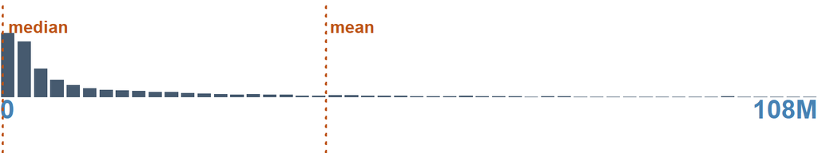

**PREVIEW**:

```
0 · 1000 · 580.187 · 500 · 938.344 · 1876.688 · 469.172 · 590.315 · 1180.631 · 2320.746
122.747 · 962.925 · 1065.585 · 1227.467 · 5801.865 · 5903.153 · 5962.929 · 532.792 · 1137.099
```

**STATS**:

| MIN | Q05 | Q25 | Q50 | MEAN | Q75 | Q95 | MAX |
| --- | --- | --- | --- | --- | --- | --- | --- |
| 0 | 0 | 1,876.69 | 355,507.1 | 43,202,098 | 3,585,903 | 108,414,349 | 17,912,549,512 |

number · measurement

exp_c3 minus grants_org_c3

`exp_c3_net`

exp_c3 minus grants_org_c3 (pass-through removed; 2012+)

| ROWS | DISTINCT | MISSING/NA | ZERO |
| --- | --- | --- | --- |
| 78,600 | 40,036 (50.9%) | 37,728 (48.0%) | 837 (1.1%) |

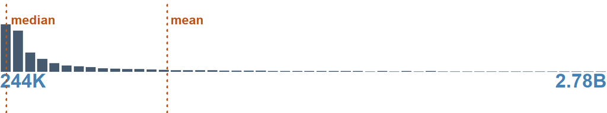

**PREVIEW**:

```
0 · 2901552.775 · 148.29 · 212.011 · 227.42 · 379.442 · 859.197 · 961.803 · 1109.75 · 1161.488
1431.103 · 1710.911 · 1912.369 · 2414.631 · 2835 · 3051.472 · 3284.537 · 3652.651 · 4290.222
```

**STATS**:

| MIN | Q05 | Q25 | Q50 | MEAN | Q75 | Q95 | MAX |
| --- | --- | --- | --- | --- | --- | --- | --- |
| 0 | 243,593.5 | 5,135,841 | 30,899,867 | 766,724,446 | 165,318,803 | 2,777,264,845 | 144,146,089,348 |

number · measurement

exp_c3_nohu minus grants paid

`exp_c3_nohu_net`

exp_c3_nohu minus grants paid (2012+)

| ROWS | DISTINCT | MISSING/NA | ZERO |
| --- | --- | --- | --- |
| 78,600 | 39,951 (50.8%) | 37,728 (48.0%) | 921 (1.2%) |

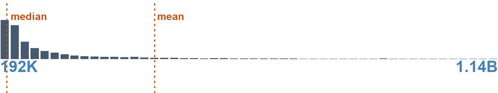

**PREVIEW**:

```
0 · 549361.601 · 2901552.775 · 148.29 · 212.011 · 227.42 · 379.442 · 609.753 · 628.449 · 859.197
961.803 · 1109.75 · 1161.488 · 1431.103 · 1510.19 · 1710.911 · 1912.369 · 1926 · 1937.234
```

**STATS**:

| MIN | Q05 | Q25 | Q50 | MEAN | Q75 | Q95 | MAX |
| --- | --- | --- | --- | --- | --- | --- | --- |
| 0 | 192,260.4 | 3,320,659 | 16,341,652 | 353,377,137 | 80,242,636 | 1,136,401,380 | 89,069,835,699 |

number · measurement

rev_c3 minus grants paid

`rev_c3_net`

rev_c3 minus grants paid (2012+)

| ROWS | DISTINCT | MISSING/NA | ZERO |
| --- | --- | --- | --- |
| 78,600 | 40,029 (50.9%) | 37,728 (48.0%) | 845 (1.1%) |

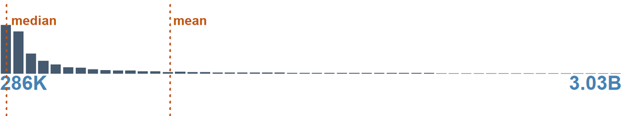

**PREVIEW**:

```
0 · 1342.564 · 2467 · 4262.196 · 4984.082 · 5903 · 7367.089 · 11793.987 · 12418.287 · 15935.403
16841.399 · 18108.782 · 19712.25 · 21423.724 · 22905.815 · 23234.812 · 24248.316 · 25273.693
```

**STATS**:

| MIN | Q05 | Q25 | Q50 | MEAN | Q75 | Q95 | MAX |
| --- | --- | --- | --- | --- | --- | --- | --- |
| 0 | 286,265 | 5,812,918 | 33,466,264 | 829,613,377 | 179,658,304 | 3,031,792,246 | 153,183,271,397 |

number · measurement

rev_c3_nohu minus grants paid

`rev_c3_nohu_net`

rev_c3_nohu minus grants paid (2012+)

| ROWS | DISTINCT | MISSING/NA | ZERO |
| --- | --- | --- | --- |
| 78,600 | 39,944 (50.8%) | 37,728 (48.0%) | 930 (1.2%) |

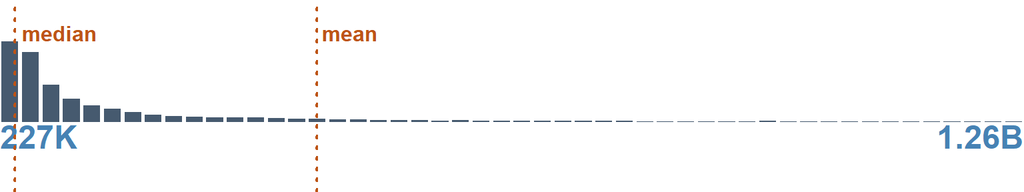

**PREVIEW**:

```
0 · 1342.564 · 2467 · 4262.196 · 4984.082 · 5903 · 7367.089 · 11202.242 · 11474.97 · 11793.987
12418.287 · 15935.403 · 16223.046 · 16841.399 · 17681.765 · 18108.782 · 19712.25 · 21423.724
```

**STATS**:

| MIN | Q05 | Q25 | Q50 | MEAN | Q75 | Q95 | MAX |
| --- | --- | --- | --- | --- | --- | --- | --- |
| 0 | 227,073.8 | 3,757,096 | 18,289,363 | 389,157,822 | 88,972,903 | 1,256,788,054 | 90,017,399,255 |

number · measurement

Contributions, gifts and grants received by active c3 filers

`con_c3`

Contributions, gifts and grants received by active c3 filers (2022 $)

| ROWS | DISTINCT | ZERO |
| --- | --- | --- |
| 78,600 | 76,098 (96.8%) | 2,497 (3.2%) |

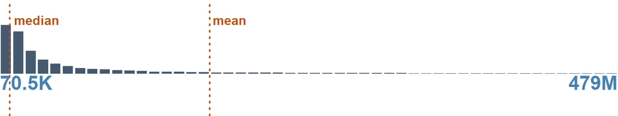

**PREVIEW**:

```
0 · 30042.802 · 56862.716 · 73276.812 · 194044.546 · 459476.166 · 579301.439 · 13.013 · 15.41
17.29 · 27.484 · 36.591 · 38.025 · 39.236 · 46.847 · 59.739 · 66.991 · 87.227 · 93.777 · 128.199
```

**STATS**:

| MIN | Q05 | Q25 | Q50 | MEAN | Q75 | Q95 | MAX |
| --- | --- | --- | --- | --- | --- | --- | --- |
| 0 | 70,507.19 | 1,395,815 | 7,756,171 | 162,793,788 | 37,098,839 | 479,193,439 | 49,925,233,985 |

number · measurement

Total assets, end of year, active c3 filers

`assets_c3`

Total assets, end of year, active c3 filers (2022 $)

| ROWS | DISTINCT | ZERO |
| --- | --- | --- |
| 78,600 | 76,335 (97.1%) | 2,258 (2.9%) |

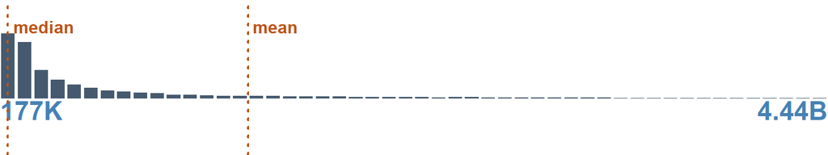

**PREVIEW**:

```
0 · 1.211 · 1.25 · 82975.613 · 109275.451 · 195457.047 · 1836518.844 · 2365752.522 · 7760660.665
1.121 · 1.137 · 1.16 · 1.193 · 1.195 · 1.282 · 2.39 · 19.23 · 82.386 · 98.526 · 295.453
```

**STATS**:

| MIN | Q05 | Q25 | Q50 | MEAN | Q75 | Q95 | MAX |
| --- | --- | --- | --- | --- | --- | --- | --- |
| 0 | 177,304.8 | 6,665,207 | 41,133,899 | 1,332,015,988 | 268,937,494 | 4,439,392,677 | 340,097,591,588 |

number

Private foundations filing a 990-PF

`n_pf`

Private foundations filing a 990-PF (no floor)

| ROWS | DISTINCT | ZERO |
| --- | --- | --- |
| 78,600 | 1,112 (1.4%) | 16,346 (20.8%) |

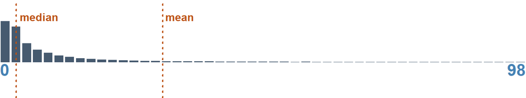

**PREVIEW**:

```
0 · 1 · 2 · 3 · 4 · 5 · 6 · 7 · 8 · 9 · 10 · 11 · 12 · 13 · 14 · 15 · 16 · 17 · 18 · 20 · 19
21 · 22 · 23 · 24 · 25 · 26 · 27 · 28 · 34 · 29 · 31 · 36 · 32 · 30 · 37 · 38 · 33 · 35 · 39
```

**STATS**:

| MIN | Q05 | Q25 | Q50 | MEAN | Q75 | Q95 | MAX |
| --- | --- | --- | --- | --- | --- | --- | --- |
| 0 | 0 | 1 | 3 | 30.32 | 11 | 97 | 5,474 |

number · measurement

Foundation assets, book value end of year

`pf_assets`

Foundation assets, book value end of year (2022 $)

| ROWS | DISTINCT | ZERO |
| --- | --- | --- |
| 78,600 | 61,868 (78.7%) | 16,139 (20.5%) |

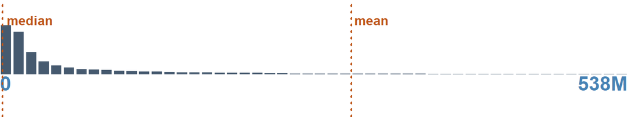

**PREVIEW**:

```
0 · 1.413 · 1.282 · 1.374 · 1.49 · 1.25 · 1.454 · 1.572 · 1.109 · 1.34 · 1.121 · 1.227 · 1.301
1.211 · 1.521 · 1.541 · 1.305 · 0.28 · 0.561 · 0.841 · 1.195
```

**STATS**:

| MIN | Q05 | Q25 | Q50 | MEAN | Q75 | Q95 | MAX |
| --- | --- | --- | --- | --- | --- | --- | --- |
| 0 | 0 | 20,224.63 | 2,330,051 | 301,152,824 | 21,403,460 | 538,226,762 | 196,072,597,259 |

number · measurement

Foundation contributions and grants paid

`pf_grants`

Foundation contributions and grants paid (2022 $)

| ROWS | DISTINCT | ZERO |
| --- | --- | --- |
| 78,600 | 54,540 (69.4%) | 21,112 (26.9%) |

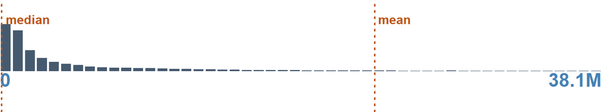

**PREVIEW**:

```
0 · 1453.606 · 1520.984 · 1489.689 · 1540.96 · 5327.925 · 1571.852 · 5962.929 · 1121.04
1281.989 · 1301.313 · 2979.379 · 770.48 · 1065.585 · 1227.467 · 1412.897 · 2217.282 · 2242.081
```

**STATS**:

| MIN | Q05 | Q25 | Q50 | MEAN | Q75 | Q95 | MAX |
| --- | --- | --- | --- | --- | --- | --- | --- |
| 0 | 0 | 0 | 117,173.5 | 23,722,704 | 1,260,222 | 38,076,785 | 16,523,714,085 |

number · measurement

Registered exempt organizations, all subsections

`n_bmf_all`

Registered exempt organizations, all subsections (reconstructed BMF stock)

| ROWS | DISTINCT | ZERO |
| --- | --- | --- |
| 78,600 | 4,875 (6.2%) | 120 (0.2%) |

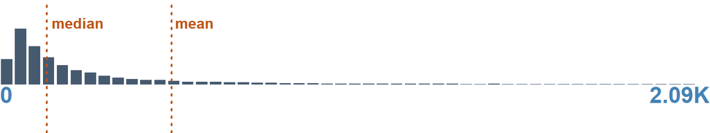

**PREVIEW**:

```
39 · 46 · 50 · 38 · 47 · 29 · 36 · 49 · 43 · 66 · 62 · 27 · 33 · 48 · 53 · 65 · 44 · 45 · 51
28 · 31 · 67 · 34 · 60 · 59 · 41 · 42 · 37 · 25 · 52 · 40 · 68 · 35 · 56 · 69 · 64 · 63 · 61
```

**STATS**:

| MIN | Q05 | Q25 | Q50 | MEAN | Q75 | Q95 | MAX |
| --- | --- | --- | --- | --- | --- | --- | --- |
| 0 | 23 | 64 | 138 | 505.46 | 340 | 2,053 | 50,774 |

number

Registered 501(c)(3) organizations

`n_bmf_c3`

Registered 501(c)(3) organizations (reconstructed stock)

| ROWS | DISTINCT | ZERO |
| --- | --- | --- |
| 78,600 | 4,187 (5.3%) | 161 (0.2%) |

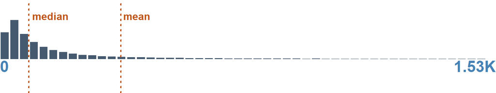

**PREVIEW**:

```
19 · 22 · 23 · 24 · 27 · 26 · 25 · 20 · 21 · 31 · 29 · 17 · 32 · 16 · 15 · 30 · 36 · 34 · 35
18 · 28 · 37 · 39 · 33 · 14 · 42 · 43 · 38 · 40 · 47 · 45 · 48 · 44 · 49 · 41 · 46 · 50 · 13
```

**STATS**:

| MIN | Q05 | Q25 | Q50 | MEAN | Q75 | Q95 | MAX |
| --- | --- | --- | --- | --- | --- | --- | --- |
| 0 | 13 | 39 | 89 | 372.77 | 232 | 1,506.05 | 46,055 |

number · measurement

Registered 501(c)(3) public charities

`n_bmf_c3pc`

Registered 501(c)(3) public charities (foundation code not 02/03/04)

| ROWS | DISTINCT | ZERO |
| --- | --- | --- |
| 78,600 | 3,944 (5.0%) | 161 (0.2%) |

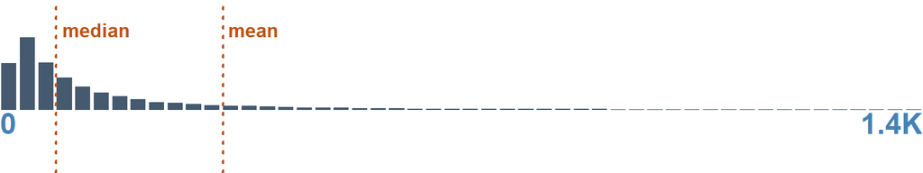

**PREVIEW**:

```
22 · 21 · 24 · 26 · 23 · 19 · 17 · 29 · 28 · 31 · 16 · 25 · 34 · 27 · 15 · 18 · 30 · 20 · 32
33 · 14 · 37 · 35 · 38 · 41 · 43 · 42 · 47 · 36 · 40 · 39 · 44 · 49 · 13 · 12 · 48 · 45 · 46
```

**STATS**:

| MIN | Q05 | Q25 | Q50 | MEAN | Q75 | Q95 | MAX |
| --- | --- | --- | --- | --- | --- | --- | --- |
| 0 | 13 | 37 | 85 | 339.05 | 218 | 1,390 | 42,414 |

number · measurement

Registered public charities excluding hospitals and universities

`n_bmf_c3pc_nohu`

Registered public charities excluding hospitals and universities

| ROWS | DISTINCT | ZERO |
| --- | --- | --- |
| 78,600 | 3,894 (5.0%) | 165 (0.2%) |

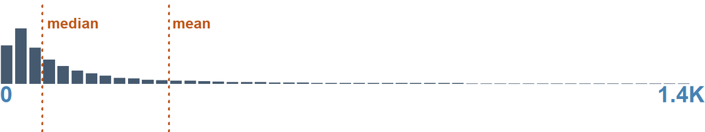

**PREVIEW**:

```
22 · 21 · 24 · 25 · 31 · 20 · 16 · 17 · 27 · 26 · 28 · 23 · 19 · 29 · 18 · 30 · 33 · 15 · 14
32 · 37 · 34 · 35 · 38 · 36 · 42 · 43 · 13 · 41 · 40 · 47 · 46 · 39 · 49 · 12 · 44 · 48 · 51
```

**STATS**:

| MIN | Q05 | Q25 | Q50 | MEAN | Q75 | Q95 | MAX |
| --- | --- | --- | --- | --- | --- | --- | --- |
| 0 | 12 | 36 | 84 | 335.65 | 216 | 1,378 | 42,107 |

number

Registered human-services public charities

`n_bmf_c3pc_hs`

Registered human-services public charities (NTEE I-P)

| ROWS | DISTINCT | ZERO |
| --- | --- | --- |
| 78,600 | 1,685 (2.1%) | 675 (0.9%) |

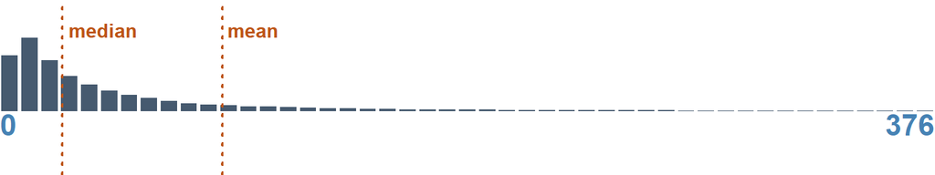

**PREVIEW**:

```
4 · 3 · 6 · 5 · 7 · 8 · 9 · 10 · 11 · 12 · 2 · 13 · 14 · 15 · 16 · 17 · 18 · 19 · 1 · 20 · 21
22 · 23 · 24 · 25 · 26 · 27 · 29 · 31 · 30 · 28 · 32 · 33 · 0 · 35 · 34 · 36 · 37 · 38 · 39 · 40
```

**STATS**:

| MIN | Q05 | Q25 | Q50 | MEAN | Q75 | Q95 | MAX |
| --- | --- | --- | --- | --- | --- | --- | --- |
| 0 | 3 | 10 | 25 | 89.57 | 64 | 372 | 10,494 |

number

Registered private foundations

`n_bmf_pf`

Registered private foundations

| ROWS | DISTINCT | ZERO |
| --- | --- | --- |
| 78,600 | 1,175 (1.5%) | 12,295 (15.6%) |

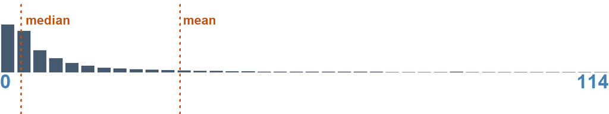

**PREVIEW**:

```
0 · 1 · 2 · 3 · 4 · 5 · 6 · 7 · 8 · 9 · 10 · 11 · 12 · 13 · 14 · 15 · 16 · 17 · 18 · 19 · 20
21 · 22 · 23 · 24 · 25 · 27 · 26 · 28 · 29 · 31 · 30 · 33 · 32 · 34 · 36 · 35 · 38 · 39 · 37
```

**STATS**:

| MIN | Q05 | Q25 | Q50 | MEAN | Q75 | Q95 | MAX |
| --- | --- | --- | --- | --- | --- | --- | --- |
| 0 | 0 | 1 | 4 | 33.72 | 12 | 113 | 6,618 |

number · measurement

Raw BMF snapshot count, all subsections

`n_bmf_all_snap`

Raw BMF snapshot count, all subsections (no gap filling)

| ROWS | DISTINCT | ZERO |
| --- | --- | --- |
| 78,600 | 4,747 (6.0%) | 122 (0.2%) |

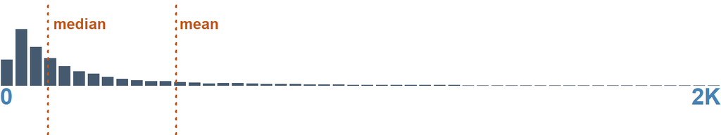

**PREVIEW**:

```
47 · 42 · 36 · 46 · 28 · 43 · 51 · 27 · 64 · 33 · 50 · 39 · 38 · 40 · 45 · 67 · 35 · 26 · 59
60 · 25 · 65 · 37 · 52 · 62 · 61 · 31 · 63 · 49 · 48 · 66 · 32 · 58 · 41 · 34 · 53 · 29 · 56
```

**STATS**:

| MIN | Q05 | Q25 | Q50 | MEAN | Q75 | Q95 | MAX |
| --- | --- | --- | --- | --- | --- | --- | --- |
| 0 | 22 | 62 | 134 | 488.63 | 329 | 1,982 | 50,555 |

number · measurement

Raw snapshot count, 501(c)(3)

`n_bmf_c3_snap`

Raw snapshot count, 501(c)(3)

| ROWS | DISTINCT | ZERO |
| --- | --- | --- |
| 78,600 | 4,064 (5.2%) | 166 (0.2%) |

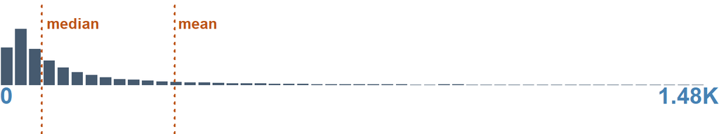

**PREVIEW**:

```
22 · 19 · 24 · 23 · 21 · 26 · 16 · 29 · 25 · 33 · 36 · 20 · 17 · 31 · 27 · 30 · 28 · 15 · 32
14 · 35 · 18 · 34 · 37 · 43 · 38 · 42 · 39 · 45 · 41 · 40 · 46 · 13 · 47 · 12 · 44 · 50 · 48
```

**STATS**:

| MIN | Q05 | Q25 | Q50 | MEAN | Q75 | Q95 | MAX |
| --- | --- | --- | --- | --- | --- | --- | --- |
| 0 | 13 | 37 | 86 | 359.51 | 225 | 1,452 | 45,993 |

number · measurement

Raw snapshot count, c3 public charities

`n_bmf_c3pc_snap`

Raw snapshot count, c3 public charities

| ROWS | DISTINCT | ZERO |
| --- | --- | --- |
| 78,600 | 3,833 (4.9%) | 166 (0.2%) |

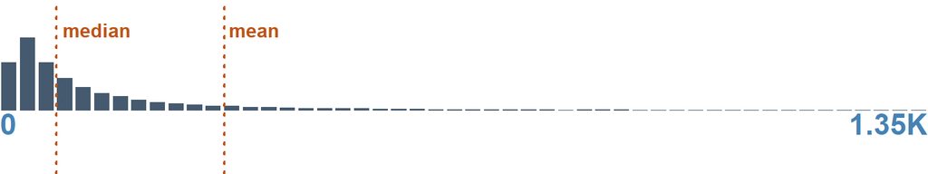

**PREVIEW**:

```
22 · 21 · 23 · 20 · 24 · 16 · 27 · 26 · 19 · 28 · 31 · 33 · 15 · 17 · 29 · 30 · 34 · 14 · 25
18 · 32 · 36 · 37 · 35 · 13 · 42 · 41 · 44 · 38 · 47 · 40 · 39 · 12 · 43 · 11 · 45 · 52 · 46
```

**STATS**:

| MIN | Q05 | Q25 | Q50 | MEAN | Q75 | Q95 | MAX |
| --- | --- | --- | --- | --- | --- | --- | --- |
| 0 | 12 | 36 | 82 | 326.53 | 211 | 1,337.05 | 41,666 |

number · measurement

Raw snapshot count, public charities excluding hospitals and univer...

`n_bmf_c3pc_nohu_snap`

Raw snapshot count, public charities excluding hospitals and universities

| ROWS | DISTINCT | ZERO |
| --- | --- | --- |
| 78,600 | 3,827 (4.9%) | 170 (0.2%) |

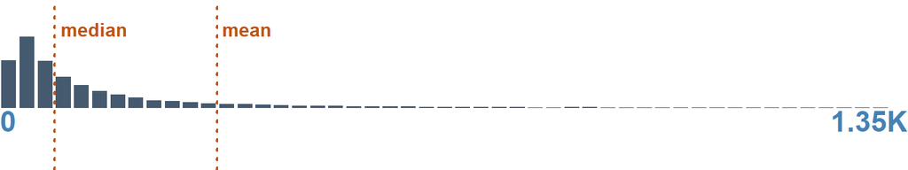

**PREVIEW**:

```
21 · 22 · 16 · 19 · 20 · 27 · 23 · 24 · 30 · 26 · 25 · 29 · 33 · 28 · 15 · 17 · 32 · 31 · 14
18 · 35 · 13 · 37 · 34 · 36 · 40 · 42 · 41 · 38 · 12 · 11 · 47 · 44 · 39 · 43 · 46 · 49 · 45
```

**STATS**:

| MIN | Q05 | Q25 | Q50 | MEAN | Q75 | Q95 | MAX |
| --- | --- | --- | --- | --- | --- | --- | --- |
| 0 | 12 | 35 | 81 | 323.22 | 209 | 1,327 | 41,403 |

number

Raw snapshot count, human-services public charities

`n_bmf_c3pc_hs_snap`

Raw snapshot count, human-services public charities

| ROWS | DISTINCT | ZERO |
| --- | --- | --- |
| 78,600 | 1,640 (2.1%) | 730 (0.9%) |

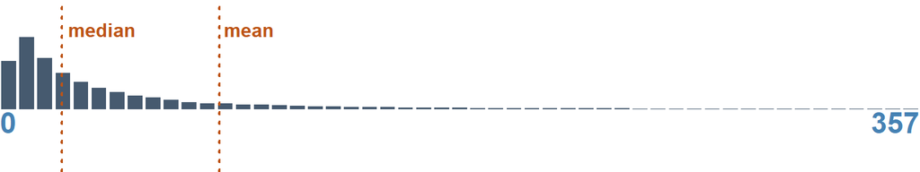

**PREVIEW**:

```
4 · 3 · 5 · 6 · 8 · 7 · 9 · 2 · 10 · 11 · 12 · 13 · 14 · 16 · 15 · 18 · 17 · 1 · 20 · 19 · 21
22 · 23 · 24 · 25 · 26 · 27 · 30 · 29 · 28 · 31 · 0 · 32 · 33 · 35 · 36 · 34 · 37 · 39 · 38 · 40
```

**STATS**:

| MIN | Q05 | Q25 | Q50 | MEAN | Q75 | Q95 | MAX |
| --- | --- | --- | --- | --- | --- | --- | --- |
| 0 | 3 | 10 | 24 | 85.15 | 62 | 353 | 10,400 |

number

Raw snapshot count, private foundations

`n_bmf_pf_snap`

Raw snapshot count, private foundations

| ROWS | DISTINCT | ZERO |
| --- | --- | --- |
| 78,600 | 1,153 (1.5%) | 12,712 (16.2%) |

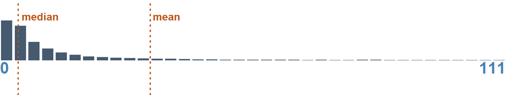

**PREVIEW**:

```
0 · 1 · 2 · 3 · 4 · 5 · 6 · 7 · 8 · 9 · 10 · 11 · 12 · 13 · 14 · 15 · 16 · 17 · 18 · 19 · 21
20 · 23 · 22 · 25 · 24 · 28 · 26 · 27 · 29 · 30 · 31 · 32 · 33 · 34 · 36 · 35 · 38 · 37 · 39
```

**STATS**:

| MIN | Q05 | Q25 | Q50 | MEAN | Q75 | Q95 | MAX |
| --- | --- | --- | --- | --- | --- | --- | --- |
| 0 | 0 | 1 | 4 | 32.97 | 12 | 110 | 6,553 |

number

Months between the snapshot used and Dec 31 of the year

`bmf_months_off`

Months between the snapshot used and Dec 31 of the year

| ROWS | DISTINCT | MISSING/NA | ZERO |
| --- | --- | --- | --- |
| 78,600 | 8 (0.0%) | 122 (0.2%) | 6,286 (8.0%) |

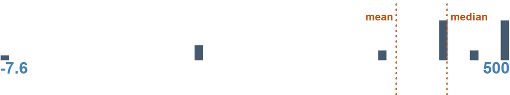

**PREVIEW**:

```
-0.5 · 0.5 · -4.5 · 0 · -1.5 · -8.6 · -7.6
```

**STATS**:

| MIN | Q05 | Q25 | Q50 | MEAN | Q75 | Q95 | MAX |
| --- | --- | --- | --- | --- | --- | --- | --- |
| -8.6 | -7.6 | -1.5 | -0.5 | -1.31 | 0.5 | 0.5 | 0.5 |

number

New 501(c)(3) registrations by ruling year

`n_entry_c3`

New 501(c)(3) registrations by ruling year

| ROWS | DISTINCT | ZERO |
| --- | --- | --- |
| 78,600 | 673 (0.9%) | 12,104 (15.4%) |

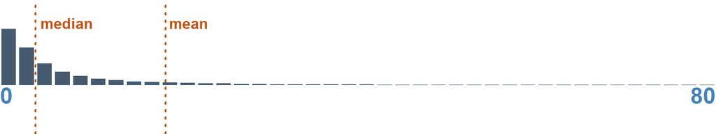

**PREVIEW**:

```
0 · 1 · 2 · 3 · 4 · 5 · 6 · 7 · 8 · 9 · 10 · 11 · 12 · 13 · 14 · 15 · 16 · 17 · 18 · 19 · 20
22 · 21 · 23 · 24 · 25 · 26 · 27 · 28 · 29 · 30 · 32 · 31 · 33 · 34 · 35 · 38 · 40 · 36 · 37
```

**STATS**:

| MIN | Q05 | Q25 | Q50 | MEAN | Q75 | Q95 | MAX |
| --- | --- | --- | --- | --- | --- | --- | --- |
| 0 | 0 | 1 | 4 | 18.52 | 11 | 79 | 2,899 |

number

New public-charity registrations

`n_entry_c3pc`